# Genome Wide Associaton Studies on Aβ42:Aβ40 Ratio Biomarker

Ryan J. Clark

2024-12-10

# Introduction

## Rationale

Individuals with Down syndrome are at an increased risk for Alzheimer’s disease. This is primarily due to the gene APP being present on chromosome 21. This gene encodes the amyloid precursor protein, which when broken down, turns into Aβ. Some isoforms of Aβ are associated with Alzheimer’s disease. Since individuals with Dwn syndrome have an extra copy of chromosome 21, APP is overexpressed, causing Alzheimer’s pathology to appear much earlier in these individuals.

## Objective

Genome wide association studies look at variants across the genome to determine association between a genotype and a trait. Eight different biomarkers commonly associated with Down syndrome were used as outcome variables to determine if there were significant variants. In this project I will go over the work flow for one of the eight biomarkers. This biomarker Aβ42 to Aβ40 is a ratio of the two main isoforms of the Aβ protein that is inversely associated with Alzheimer’s disease.

# Importing Data

The genotype data for all of the chromosomes besides chromosome 21 were handled separately in a binary plink file which is a filetype for storing genomic information. This file was processed with a bash script with UNIX. Chromosome 21 variants were made available separately in a text file since plink cannot work with trisomy data. The phenotype and participant information were stored in a text file.

```r
Phenotype <- read.delim("Phenotype.txt")

CHR21 <- read.delim("CHR21.txt", sep = "")
```

## CHR21 Quality Control

```r
library(tidyverse)
```

```r
#Calculating missingness for variants
Variant_Missingness <- rowMeans(is.na(CHR21))

CHR_21_Filtered <- CHR21 %>%
  filter(Variant_Missingness < 0.05)

#Partipant columns are in columns 8 through 429
Participant_Columns <- 8:429

Sample_Missingness <- CHR_21_Filtered %>%
  select(all_of(Participant_Columns)) %>%
  map_dbl(~ sum(is.na(.)) / nrow(CHR_21_Filtered))

Failing_Samples <- names(Sample_Missingness[Sample_Missingness > 0.05])

CHR_21_Filtered_2 <- CHR_21_Filtered %>%
  select(-all_of(Failing_Samples))
```

## Phenotype Quality Control

Since the vast majority of the cohort was white, only these white individuals were included due to differences in minor allele frequencies. Siblings of individuals with Down sydrome were included as controls. THis is not a case-control study so these controls were removed. 375 of 438 individuals passed.

```r
Phenotype_White <- Phenotype %>%
  filter(Race == "White")

Phenotype_Filtered <- Phenotype_White %>%
  filter(DS_Cases_Control==1)
```

## Covariates

For covariates to be used in the model, you to see uniform distribution so that the data is representative of the population.

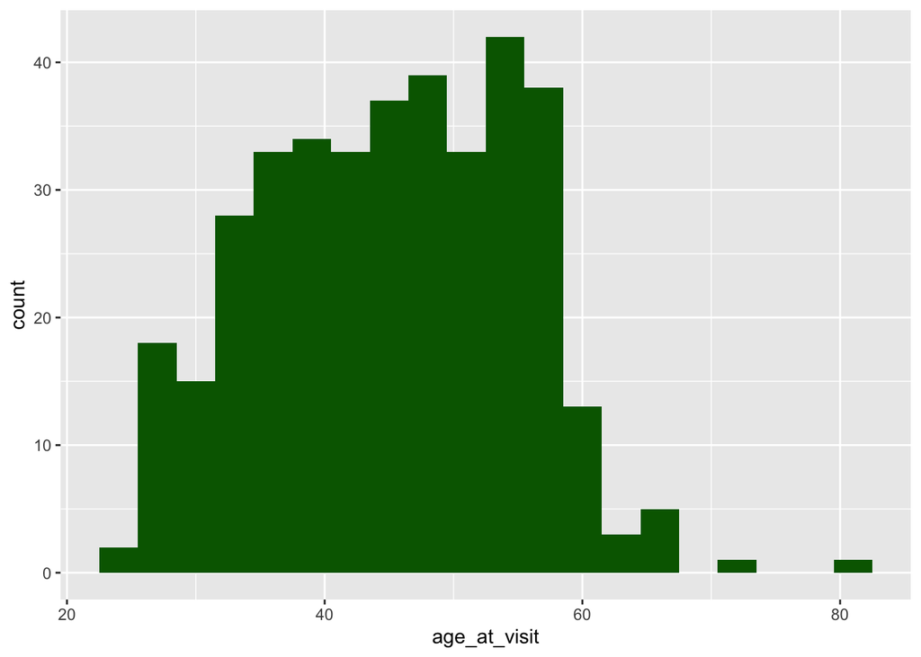

```r
ggplot(Phenotype_Filtered, aes(x = age_at_visit)) +
  geom_histogram(fill = "darkgreen", binwidth = 3)
```

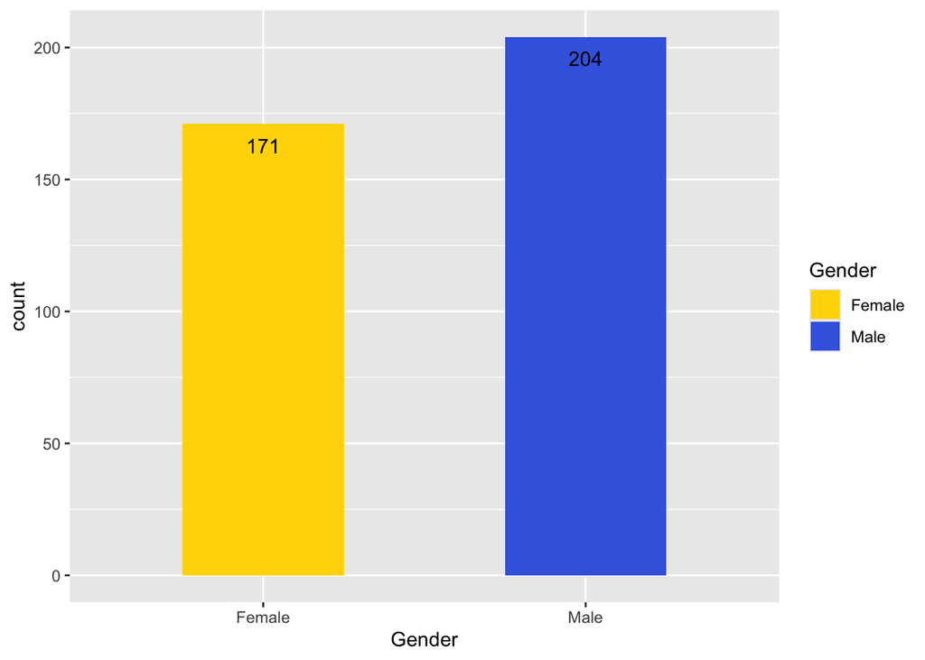

```r
ggplot(Phenotype_Filtered, aes(x = Gender, fill = Gender)) +
  geom_bar(width = 0.5, stat = "count") +
  geom_text(aes(label = ..count..), stat = "count", vjust = 2)+
  scale_fill_manual(values = c("Female" = "gold", "Male" = "royalblue"))
```

## Biomarker Normalization

Normality is a statistical assumption of outcome variables in regression models. The biomarker data ws not normally distributed. Since biomarkers were used as the outcome variable in the regression model, I used rank based inverse normal transformation to normalize the biomarker.

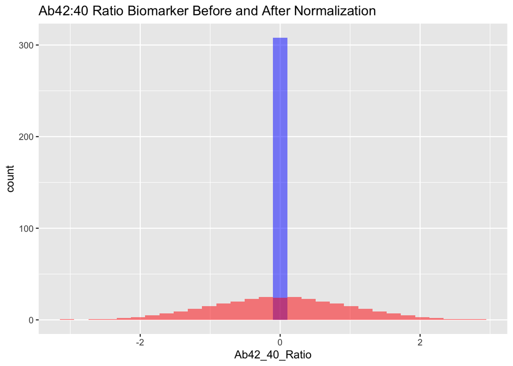

```r
library(ggplot2)
#Defining normalization function
inverse.normalize <- function(i) {

  stopifnot(is.vector(i, mode = "numeric"))

  qnorm((rank(i,
              na.last = "keep",
              ties.method = "random"
  ) - 0.5) / sum(!is.na(i)))

}

Phenotype_Filtered$inv_Ab42_40_Ratio <- inverse.normalize(Phenotype_Filtered$Ab42_40_Ratio)

#Making a histogram of both

ggplot(Phenotype_Filtered) +
  geom_histogram(aes(x = Ab42_40_Ratio), fill = "blue", alpha = 0.5, bins = 30) +
  geom_histogram(aes(x = inv_Ab42_40_Ratio), fill = "red", alpha = 0.5, bins = 30) +
  labs(title = "Ab42:40 Ratio Biomarker Before and After Normalization")
```

# CHR21 Linear Model

A linear model was used for both the chromosome 21 data with Matrix eQTL, and the rest of the autosome data from plink.

Matrix eQTL invovled converting the biomarker, variant, and covariate data into separate matrices in order to test for association. Plink can accomplish this with a small UNIX script.

## Linear Model: Biomarker ~ Variant + Age + Sex + PCs 1:4

# Merging Data from the two models

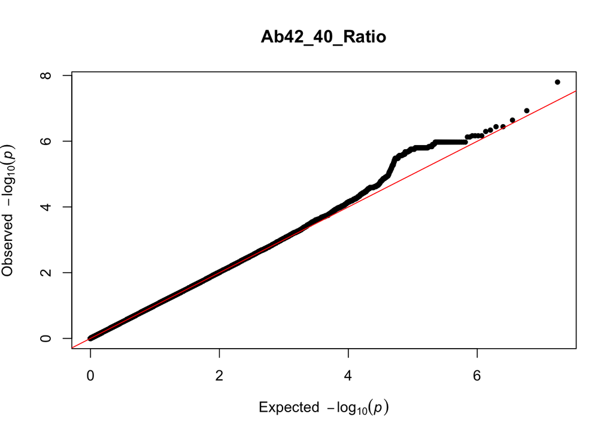

```r
library(tidyverse)
library(qqman)
#Reading in CHR21 and autosome results
ABCDS_Ab42_40_Ratio.assoc <- read.table("~/Documents/Thesis_Data/ABCDS_inv_Ab42_40_Ratio.assoc.frq", header=TRUE, quote="", comment.char="")

MEQTL_Results_Ab42_40_Ratio <- read.delim("~/Documents/Thesis_Data/MEQTL_Results_inv_Ab42_40_Ratio", quote="")

#Using regular expressions to make CHR and BP columns from SNP naming
MEQTL_Results_Ab42_40_Ratio$CHR <- sub(":.*", "", MEQTL_Results_Ab42_40_Ratio$SNP)

MEQTL_Results_Ab42_40_Ratio$BP <- sub(".*:(\\d+)\\[.*", "\\1", MEQTL_Results_Ab42_40_Ratio$SNP)

#reordering columns to match autosomes, making columns match.

MEQTL_Results_Ab42_40_Ratio <- MEQTL_Results_Ab42_40_Ratio %>% select(CHR, BP, everything())

MEQTL_Results_Ab42_40_Ratio <- MEQTL_Results_Ab42_40_Ratio %>% rename(P = p.value)

MEQTL_Results_Ab42_40_Ratio <- MEQTL_Results_Ab42_40_Ratio %>% select(CHR,BP,SNP,P)

ABCDS_Ab42_40_Ratio.assoc <- ABCDS_Ab42_40_Ratio.assoc %>% select(CHR,BP,SNP,P)

MEQTL_Results_Ab42_40_Ratio$CHR <- as.numeric(MEQTL_Results_Ab42_40_Ratio$CHR)

MEQTL_Results_Ab42_40_Ratio$BP <- as.numeric(MEQTL_Results_Ab42_40_Ratio$BP)

Ab42_40_Ratio_Complete <- bind_rows(MEQTL_Results_Ab42_40_Ratio, ABCDS_Ab42_40_Ratio.assoc)

Ab42_40_Ratio_Complete <- Ab42_40_Ratio_Complete %>% arrange(CHR,BP)

#This is for the qqplot
qq(Ab42_40_Ratio_Complete$P, main= "Ab42_40_Ratio")
```

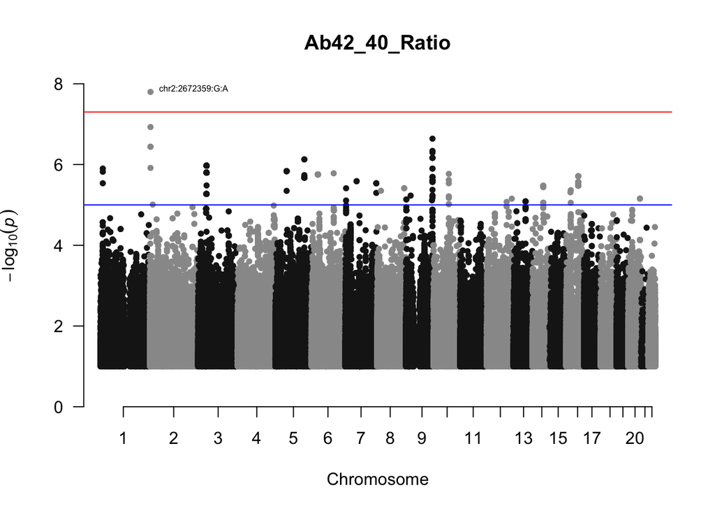

```r
#Removed p-values that do not add anything to the plot for quicker plotting.
Ab42_40_Ratio_Complete <- Ab42_40_Ratio_Complete %>%
  filter(-log10(P)>1)

manhattan(Ab42_40_Ratio_Complete, chr="CHR", bp="BP", snp="SNP", p="P", main= "Ab42_40_Ratio", annotatePval = 5e-8)
```

# Post GWAS Analysis

Since we have a significant variant genome wide (5e-8), we can look at that region via a locuszoom plot.

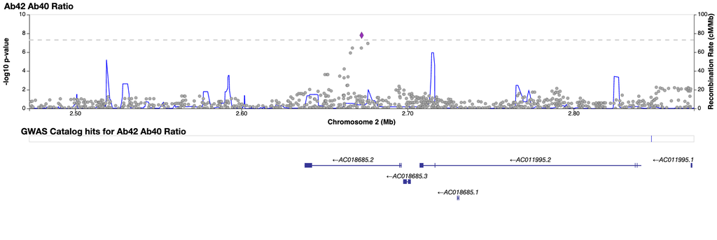

```r
library(knitr)
include_graphics("AB4240_LZ.png")
```

AC018685.2 is a non-protein coding gene. Further examination with with a gene expression database (GTEx) shows that this gene is primarily expressed in the brain. The closest protein coding gene is MYT1L in which mutations have previously been linked with cognitive disabilities.

# Conclusions

1.) Working with trisomy data was a unique challenge for this analysis.

2.) Finding genome wide significance with a smaller sample size (375) was exciting.

3.) Removing other races may increase statistical power with minor allele frequencies, but limits generizability to the greater population

4.) This is one of the eight biomarkers I conducted this workflow on.

5.) The nearest protein coding gene was not really close (over 300kbp) so I am skeptical of the influence of the non-protein coding gene from this biomarker.